# From EHR visit records to fitted biomarker trajectories

This workflow starts with a participant roster and a separate table of clinic visits. It fits the four CIMEHR variants, inspects their estimation stages, and constructs baseline and population mean curves using simulated data with 1,000 participants. The generating parameters and random seed are stored in `cimehr_example$truth`. `Y` is a simulated continuous outcome in arbitrary units, not a clinical laboratory measurement. See `?cimehr_example` for the generating equations and parameter values.

CIMEHR distinguishes a clinic visit from recording a particular biomarker at that visit. The roster must include eligible participants without visits, and the visit table must include visits at which this biomarker was not recorded. A table containing only observed biomarker values cannot reconstruct that information.

## 1. Prepare the participant and visit data

```r
library(CIMEHR)
data("cimehr_example", package = "CIMEHR")
participants <- cimehr_example$participants
visits <- cimehr_example$visits
truth <- cimehr_example$truth
cimehr_example$truth[c("seed", "n")]
```

```
#> $seed
#> [1] 200000013
#>
#> $n
#> [1] 1000
```

```r
head(participants)
```

```
#>   id Z          X  C
#> 1  1 0 -1.2844028 60
#> 2  2 0 -0.1889868 60
#> 3  3 0  1.0594535 60
#> 4  4 0 -0.8437869 60
#> 5  5 0 -1.5387287 60
#> 6  6 0 -1.2058982 60
```

```r
head(visits)
```

```
#>   id       time         Y R
#> 1  1  0.9108898 -1.860342 1
#> 2  1  1.6369347        NA 0
#> 3  1  5.4370152        NA 0
#> 4  1  8.5902001 -1.670439 1
#> 5  1  8.6748287 -1.478690 1
#> 6  1 22.5813917 -2.543885 1
```

The participant table contains one row per eligible participant. `C` is their end of follow-up in months; it is 60 for every participant in these data. `Z` is a binary exposure and `X` is a continuous baseline covariate. The visit table contains actual clinic visits only: `R = 0` means that the visit occurred but the biomarker is missing.

The supplied `Z` is already numeric. The following round trip illustrates how to encode an exposure stored as a factor without changing its original 0/1 values. `Reference` is the reference group. For a factor with more levels, retain the non-intercept columns from `model.matrix()` and use the same coding for prediction profiles.

```r
stopifnot(!anyDuplicated(participants$id),
          all(visits$id %in% participants$id),
          all(participants$Z %in% c(0, 1)))
original_Z <- participants$Z
participants$group <- factor(participants$Z, levels = c(0, 1),
                             labels = c("Reference", "Exposed"))
group_matrix <- model.matrix(~ group, data = participants)
participants$Z <- unname(group_matrix[, "groupExposed"])
stopifnot(all(participants$Z == original_Z))

analysis_data <- merge(participants, visits, by = "id", all.x = TRUE,
                       sort = FALSE)
analysis_data <- analysis_data[order(analysis_data$id, analysis_data$time,
                                    na.last = TRUE), ]
rownames(analysis_data) <- NULL

no_visit <- is.na(analysis_data$time)
stopifnot(all(is.na(analysis_data$R[no_visit])),
          all(is.na(analysis_data$Y[no_visit])),
          all(analysis_data$R[!no_visit] %in% c(0, 1)))
measured <- !no_visit & analysis_data$R == 1
unmeasured_visit <- !no_visit & analysis_data$R == 0
stopifnot(all(is.finite(analysis_data$Y[measured])),
          all(is.na(analysis_data$Y[unmeasured_visit])))

sample_counts <- data.frame(
  eligible_participants = nrow(participants),
  participants_with_visits = length(unique(visits$id)),
  participants_with_measurements = length(unique(analysis_data$id[measured])),
  clinic_visits = nrow(visits),
  recorded_measurements = sum(measured)
)
sample_counts
```

```
#>   eligible_participants participants_with_visits participants_with_measurements
#> 1                  1000                      997                            903
#>   clinic_visits recorded_measurements
#> 1         15343                  9295
```

Do not replace an unrecorded biomarker by zero. The missing outcome and its recording indicator have different roles. Participants without visits contribute to the visiting-process risk sets; actual visits contribute recording indicators; recorded biomarker values contribute to the outcome equation. Here follow-up starts at zero, and visiting risk sets are `(0, C]`. For delayed entry, supply an additional participant-level entry-time column through `entry_col`.

The simulation follows the CIMEHR shared-latent-variable construction. A standard normal shared variable drives lognormal visiting frailty and the conditional means of the recording and outcome random effects. Their residual random effects are generated independently conditional on that shared variable and the baseline covariates. Follow-up ends at 60 months for every participant. The common outcome baseline is $-2 + 0.1t$, with fixed coefficients $\beta_Z=-0.5$ and $\beta_X=0.5$. The reproducible generator is installed at `system.file("examples", "simulate_example.R", package = "CIMEHR")`.

## 2. State the designs and fit the four variants

The example uses `Z` and `X` in all three fixed-effects designs. Both the recording and outcome random-effects designs contain an intercept and `Z`. The intercepts are supplied by CIMEHR: do not add a constant fixed-effect column to the visiting or outcome design. The population exposure contrast is constant over time in these data; the random coefficient of `Z` describes individual heterogeneity and is not a fixed exposure-by-time interaction.

All covariate sets and the follow-up column are specified explicitly, so the model does not depend on differences between wrapper defaults. `CIMEHR()` uses native argument names, whereas `fit_method()` supplies a shared interface across methods; this workflow consistently uses `fit_method()`.

```r
method_keys <- c("cimehr", "cimehr_hl", "cimehr_spline", "cimehr_spline_hl")
method_labels <- setNames(c("CIMEHR", "CIMEHR-HL", "CIMEHR-spline",
                            "CIMEHR-spline-HL"), method_keys)
model_arguments <- list(
  data = analysis_data,
  id = "id", time = "time", outcome = "Y",
  obs_indicator = "R", censor_col = "C",
  visit_covs = c("Z", "X"),
  cimehr_visit_covs = c("Z", "X"),
  obs_fixed_covs = c("Z", "X"),
  long_covs = c("Z", "X"),
  outcome_random_covs = "Z", obs_random_covs = "Z",
  outcome_random_intercept = TRUE
)

fits <- setNames(lapply(method_keys, function(key) {
  do.call(fit_method, c(list(method = key), model_arguments))
}), method_keys)
```

CIMEHR uses the ordinary Laplace posterior approximation; CIMEHR-HL uses higher-order corrected posterior moments. The spline versions replace the unspecified common outcome baseline by a regression spline. They are different estimation choices, so their finite-sample estimates need not be identical. Higher-order approximation does not guarantee smaller bias for every dataset. The spline fits use the package default of five baseline spline degrees of freedom, with knot locations determined from the observed visit times. To model a time-varying exposure contrast in a spline fit, specify `trajectory_covars = "Z"` and its spline settings deliberately; that changes the fixed mean design and the interpretation of `beta.Z`. It is not the fixed effect used to generate these data, so this workflow leaves it off.

## 3. Inspect estimates and uncertainty by stage

```r
outcome_results <- do.call(rbind, lapply(names(fits), function(key) {
  tab <- summary_outcome(fits[[key]])
  theta0 <- if ("theta.Intercept" %in% tab$parameter)
    "theta.Intercept" else "theta.(Intercept)"
  at <- match(c("beta.Z", "beta.X", theta0, "theta.Z"), tab$parameter)
  stopifnot(!anyNA(at))
  tab <- tab[at, ]
  data.frame(
    method = unname(method_labels[key]),
    parameter = c("beta_Z", "beta_X", "theta_0", "theta_Z"),
    truth = as.numeric(c(truth$beta[c("Z", "X")], truth$theta[c("b0", "bZ")])),
    estimate = tab$estimate, se = tab$se, lower = tab$lower, upper = tab$upper,
    inference_valid = tab$inference_valid, row.names = NULL
  )
}))
outcome_display <- data.frame(
  Method = outcome_results$method, Parameter = outcome_results$parameter,
  Truth = outcome_results$truth, Estimate = outcome_results$estimate,
  SE = outcome_results$se,
  `95% CI` = sprintf("(%.4f, %.4f)", outcome_results$lower,
                    outcome_results$upper), check.names = FALSE
)
knitr::kable(outcome_display, digits = 4, row.names = FALSE,
             caption = paste("Outcome fixed-effect and shared-loading estimates.",
                             "SEs and 95% CIs use the fitted stacked covariance."))
```

Outcome fixed-effect and shared-loading estimates. SEs and 95% CIs use the fitted stacked covariance.

| Method | Parameter | Truth | Estimate | SE | 95% CI |
| --- | --- | --- | --- | --- | --- |
| CIMEHR | beta_Z | -0.5 | -0.4916 | 0.1581 | (-0.8014, -0.1818) |
| CIMEHR | beta_X | 0.5 | 0.5167 | 0.0861 | (0.3479, 0.6855) |
| CIMEHR | theta_0 | 0.5 | 0.4372 | 0.0759 | (0.2885, 0.5859) |
| CIMEHR | theta_Z | 0.2 | 0.2398 | 0.1520 | (-0.0581, 0.5377) |
| CIMEHR-HL | beta_Z | -0.5 | -0.4874 | 0.1539 | (-0.7891, -0.1857) |
| CIMEHR-HL | beta_X | 0.5 | 0.5145 | 0.0860 | (0.3458, 0.6831) |
| CIMEHR-HL | theta_0 | 0.5 | 0.4311 | 0.0747 | (0.2846, 0.5775) |
| CIMEHR-HL | theta_Z | 0.2 | 0.2382 | 0.1499 | (-0.0557, 0.5320) |
| CIMEHR-spline | beta_Z | -0.5 | -0.5062 | 0.1481 | (-0.7965, -0.2159) |
| CIMEHR-spline | beta_X | 0.5 | 0.5157 | 0.0779 | (0.3629, 0.6685) |
| CIMEHR-spline | theta_0 | 0.5 | 0.4148 | 0.0631 | (0.2912, 0.5385) |
| CIMEHR-spline | theta_Z | 0.2 | 0.2810 | 0.1406 | (0.0053, 0.5566) |
| CIMEHR-spline-HL | beta_Z | -0.5 | -0.5006 | 0.1443 | (-0.7834, -0.2178) |
| CIMEHR-spline-HL | beta_X | 0.5 | 0.5135 | 0.0779 | (0.3609, 0.6662) |
| CIMEHR-spline-HL | theta_0 | 0.5 | 0.4088 | 0.0621 | (0.2870, 0.5305) |
| CIMEHR-spline-HL | theta_Z | 0.2 | 0.2793 | 0.1387 | (0.0074, 0.5512) |

Here `beta.Z` is the adjusted mean biomarker difference comparing `Z = 1` with `Z = 0`, and `beta.X` is the adjusted difference per unit increase in `X`. The `theta_0` and `theta_Z` rows are population loading parameters in $E(b_i\mid U_i)=\theta U_i$; they are not estimated patient-specific random effects. The fixed-effect coefficients describe associations under the fitted model, not causal effects. Because the example outcome was not log-transformed, these coefficients and the curves below are in the same arbitrary outcome units. For an analysis fitted to a log-transformed outcome, the returned mean curves remain on the log scale; simply exponentiating them does not produce an arithmetic mean on the original scale.

Inspect the nuisance stages separately, rather than treating every coefficient returned by `coef()` as an outcome association.

```r
all_stage_results <- do.call(rbind, lapply(names(fits), function(key) {
  do.call(rbind, lapply(c("visiting", "observation", "outcome"), function(stage) {
    tab <- switch(stage,
      visiting = summary_visiting(fits[[key]]),
      observation = summary_observation(fits[[key]]),
      outcome = summary_outcome(fits[[key]]))
    data.frame(method = unname(method_labels[key]), stage = stage,
      tab[, c("parameter", "estimate", "se", "lower", "upper",
              "inference_valid", "inference_status")], row.names = NULL)
  }))
}))
summary_visiting(fits[["cimehr"]])
```

```
#>     parameter    stage  estimate         se    variance_type point_valid  df
#> 1     gamma.Z visiting 0.4154337 0.04481211 stacked_sandwich        TRUE Inf
#> 2     gamma.X visiting 0.1777853 0.02319115 stacked_sandwich        TRUE Inf
#> 3 sigma2_zeta visiting 0.3460170 0.02726669 stacked_sandwich        TRUE Inf
#>   boundary parameter_boundary fit_boundary se_available se_status
#> 1    FALSE              FALSE        FALSE         TRUE available
#> 2    FALSE              FALSE        FALSE         TRUE available
#> 3    FALSE              FALSE        FALSE         TRUE available
#>   regular_inference_valid ci_available inference_valid
#> 1                    TRUE         TRUE            TRUE
#> 2                    TRUE         TRUE            TRUE
#> 3                    TRUE         TRUE            TRUE
#>   conditional_inference_available     lower     upper regular_lower
#> 1                            TRUE 0.3276036 0.5032639     0.3276036
#> 2                            TRUE 0.1323315 0.2232391     0.1323315
```

[output cut: 17 more lines]

```r
summary_observation(fits[["cimehr"]])
```

```
#>              parameter       stage    estimate         se    variance_type
#> 1    alpha.(Intercept) observation  0.20822899 0.03074471 stacked_sandwich
#> 2              alpha.Z observation -0.40589257 0.06877829 stacked_sandwich
#> 3              alpha.X observation -0.01118036 0.02987323 stacked_sandwich
#> 4    delta.(Intercept) observation  0.17652825 0.03442502 stacked_sandwich
#> 5              delta.Z observation  0.77214593 0.06636912 stacked_sandwich
#> 6 sigma2_q.(Intercept) observation  0.18668956 0.02313340 stacked_sandwich
#> 7           sigma2_q.Z observation  0.24590200 0.05512989 stacked_sandwich
#>   point_valid  df boundary parameter_boundary fit_boundary se_available
#> 1        TRUE Inf    FALSE              FALSE        FALSE         TRUE
#> 2        TRUE Inf    FALSE              FALSE        FALSE         TRUE
#> 3        TRUE Inf    FALSE              FALSE        FALSE         TRUE
#> 4        TRUE Inf    FALSE              FALSE        FALSE         TRUE
#> 5        TRUE Inf    FALSE              FALSE        FALSE         TRUE
#> 6        TRUE Inf    FALSE              FALSE        FALSE         TRUE
```

[output cut: 49 more lines]

```r
confint(fits[["cimehr"]])
```

```
#>                       lower      upper
#> beta.Z          -0.80144087 -0.1817999
#> beta.X           0.34792374  0.6854934
#> theta.Intercept  0.28847581  0.5858832
#> theta.Z         -0.05809648  0.5377308
```

The default `inference = "stacked"` propagates the available identifiable visiting-, recording-, and outcome-stage uncertainty, including their cross-stage covariance. At a selected variance boundary its scope can be conditional on that branch or face. `ci_available` means that numerical limits are present; read `inference_status`, `inference_scope`, and `inference_reason` as well. A conditional interval is not a guarantee of coverage after selecting the boundary model. Descriptive weak-identification warnings do not erase computed intervals, and do not certify those intervals as reliable under weak identification. Confirmed fitting or covariance failures are reported separately.

```r
fit <- fits[["cimehr"]]
outcome_diagnostics <- summary_outcome(fit)
outcome_diagnostics[, c("parameter", "ci_available", "inference_valid",
                        "inference_status", "inference_reason")]
```

```
#>         parameter ci_available inference_valid inference_status
#> 1          beta.Z         TRUE            TRUE          regular
#> 2          beta.X         TRUE            TRUE          regular
#> 3 theta.Intercept         TRUE            TRUE          regular
#> 4         theta.Z         TRUE            TRUE          regular
#>              inference_reason
#> 1 regular inference available
#> 2 regular inference available
#> 3 regular inference available
#> 4 regular inference available
```

```r
fit$diagnostics$warnings
```

```
#> character(0)
```

## 4. Construct baseline and population trajectories

`meanfit()` returns a curve object; calling `plot()` on that object does not refit the model. By default no bootstrap is run and no curve intervals are computed. The same commands work for each of the four fitted variants.

```r
time_grid <- seq(0, 60, length.out = 121L)
profiles <- data.frame(Z = c(0, 1), X = c(0, 0))
profiles
```

```
#>   Z X
#> 1 0 0
#> 2 1 0
```

```r
baseline_curves <- lapply(fits, meanfit, type = "baseline", times = time_grid)
profile_curves <- lapply(fits, meanfit, newdata = profiles, times = time_grid)
head(as.data.frame(baseline_curves[["cimehr"]]))
```

```
#>   time       fit
#> 1  0.0 -2.128804
#> 2  0.5 -2.066755
#> 3  1.0 -2.006914
#> 4  1.5 -1.947746
#> 5  2.0 -1.887326
#> 6  2.5 -1.827903
```

```r
head(as.data.frame(profile_curves[["cimehr"]]))
```

```
#>   profile time       fit
#> 1       1  0.0 -2.128804
#> 2       1  0.5 -2.066755
#> 3       1  1.0 -2.006914
#> 4       1  1.5 -1.947746
#> 5       1  2.0 -1.887326
#> 6       1  2.5 -1.827903
```

The baseline curve is the common mean for the zero fixed-covariate profile (`Z = 0`, `X = 0`). The population trajectories average random effects to their model population mean and compare the two supplied profiles, rather than predicting particular patients’ random effects. With `newdata`, each row defines one curve. The legend’s profile numbers correspond to the rows shown above.

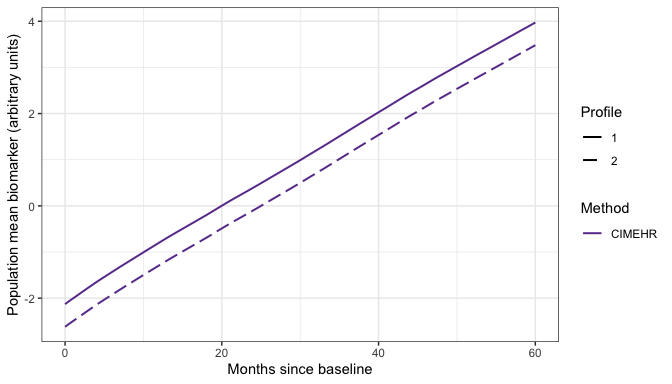

```r
plot(profile_curves[["cimehr"]], xlab = "Months since baseline",
     ylab = "Population mean biomarker (arbitrary units)")
```

Ordinary CIMEHR recovers the baseline by local smoothing of compensated increments; spline fits evaluate their fitted basis directly. For local recovery, `bandwidth` is in the time units of the fit. Sparse regions can have unavailable curve points. Changing the bandwidth changes this post-estimation smoothing, not the original fitted coefficients. Do not extrapolate beyond the stored follow-up range.

To average over a common participant population, supply its profiles explicitly. This also makes the target population clear when comparing methods that retain different participant subsets.

```r
reference_profiles <- participants[, c("Z", "X")]
standardized <- meanfit(fits[["cimehr"]], newdata = reference_profiles,
                        aggregate = TRUE, times = time_grid)
head(summary(standardized))
```

```
#>   time       fit
#> 1  0.0 -2.398563
#> 2  0.5 -2.336514
#> 3  1.0 -2.276673
#> 4  1.5 -2.217505
#> 5  2.0 -2.157085
#> 6  2.5 -2.097662
```

## 5. Request pointwise 95% intervals explicitly

For the spline fits, the joint coefficient covariance includes the baseline spline uncertainty, so `se.fit = TRUE` can give analytical pointwise intervals. Ordinary CIMEHR coefficient SEs alone do not include recovered-baseline uncertainty; use the participant bootstrap for its curve intervals.

```r
spline_intervals <- meanfit(fits[["cimehr_spline"]], newdata = profiles,
                            times = time_grid, se.fit = TRUE, conf.int = .95)
head(summary(spline_intervals))
```

```
#>   profile time       fit         se     lower     upper
#> 1       1  0.0 -2.071374 0.08487869 -2.237734 -1.905015
#> 2       1  0.5 -2.017641 0.08202584 -2.178409 -1.856874
#> 3       1  1.0 -1.963914 0.07930879 -2.119357 -1.808472
#> 4       1  1.5 -1.910200 0.07674485 -2.060617 -1.759782
#> 5       1  2.0 -1.856503 0.07435081 -2.002228 -1.710778
#> 6       1  2.5 -1.802830 0.07214251 -1.944227 -1.661434
```

The bootstrap is opt-in. The following calls request it explicitly for each method and curve type. Its default is `B = 50L`; the variable below shows where to change the number of resamples. Each resample draws whole participants, including zero-visit participants, and refits all three stages. Cached nuisance fits are not reused.

For the population figure, the target is an equal mixture of `Z = 0` and `Z = 1`, both at `X = 0`. This differs from averaging over the empirical participant distribution above. Its generating mean is $-2.25+0.1t$; the common baseline is $-2+0.1t$. The grid spans months 0 to 60 at 121 points. The local-smoothing bandwidth is 12 months for ordinary CIMEHR and CIMEHR-HL; spline methods evaluate their fitted basis directly.

```r
B <- 50L
bootstrap_seed <- 20261014L
profile_weights <- c(.5, .5)
population_intercept <- truth$baseline_intercept +
  sum(profile_weights * (truth$beta["Z"] * profiles$Z +
                         truth$beta["X"] * profiles$X))
bootstrap_curves <- list()
curve_rows <- list()
bootstrap_rows <- list()
for (key in names(fits)) {
  for (type in c("baseline", "population")) {
    args <- list(object = fits[[key]], type = type, times = time_grid,
                 bandwidth = 12, bootstrap = TRUE, B = B,
                 seed = bootstrap_seed, workers = 1L, conf.int = .95)
    if (type == "population") {
      args$newdata <- profiles
      args$aggregate <- TRUE
      args$weights <- profile_weights
    }
    curve <- do.call(meanfit, args)
    name <- paste(key, type)
    bootstrap_curves[[name]] <- curve
    tab <- as.data.frame(curve)
    tab$method <- unname(method_labels[key])
    tab$type <- type
    intercept <- if (type == "baseline") truth$baseline_intercept else
      population_intercept
    tab$truth <- intercept + truth$baseline_slope * tab$time
    curve_rows[[name]] <- tab
    bootstrap_rows[[name]] <- data.frame(
      method = unname(method_labels[key]), type = type, B = B,
      successful = curve$bootstrap$successful_fits, n_points = nrow(tab),
      min_n_boot = min(tab$n_boot),
      max_absolute_curve_error = max(abs(tab$fit - tab$truth)),
      all_finite_CI = all(is.finite(tab$lower) & is.finite(tab$upper))
    )
  }
}
curve_results <- do.call(rbind, curve_rows)
curve_results$method <- factor(curve_results$method,
                               levels = unname(method_labels))
bootstrap_summary <- do.call(rbind, bootstrap_rows)
```

The bootstrap above refits every stage 50 times for each method and curve type, which takes several minutes, so it is not rerun when this vignette is built. The results below were produced by exactly that code and are installed with the package:

```r
results_directory <- system.file("examples", "results", package = "CIMEHR")
curve_results <- read.csv(file.path(results_directory,
                                    "baseline_population_curves.csv"))
curve_results$method <- factor(curve_results$method,
                               levels = unname(method_labels))
bootstrap_summary <- read.csv(file.path(results_directory,
                                        "bootstrap_summary.csv"))
```

The curve SE is the sample standard deviation of finite bootstrap estimates, not that standard deviation divided by the square root of `B`. Intervals use the original fitted curve plus or minus the normal critical value times this SE. They quantify pointwise uncertainty in the fitted mean, not prediction intervals for future individual biomarker values.

Inspect the number of usable bootstrap estimates at each time. Failed attempts are recorded and are not replaced by new samples. Use more resamples when stable final interval estimates are required. A parent analytical-covariance failure alone does not invalidate full-refit bootstrap variability; the parent point fit must still be valid, and the bootstrap has its own assumptions and diagnostics.

```r
knitr::kable(bootstrap_summary[, c("method", "type", "B", "successful",
                                  "n_points", "min_n_boot", "all_finite_CI")],
             row.names = FALSE,
             col.names = c("Method", "Curve", "Resamples", "Successful fits",
                           "Time points", "Minimum usable resamples",
                           "Finite intervals"))
```

| Method | Curve | Resamples | Successful fits | Time points | Minimum usable resamples | Finite intervals |
| --- | --- | --- | --- | --- | --- | --- |
| CIMEHR | baseline | 50 | 50 | 121 | 50 | TRUE |
| CIMEHR | population | 50 | 50 | 121 | 50 | TRUE |
| CIMEHR-HL | baseline | 50 | 50 | 121 | 50 | TRUE |
| CIMEHR-HL | population | 50 | 50 | 121 | 50 | TRUE |
| CIMEHR-spline | baseline | 50 | 50 | 121 | 50 | TRUE |
| CIMEHR-spline | population | 50 | 50 | 121 | 50 | TRUE |
| CIMEHR-spline-HL | baseline | 50 | 50 | 121 | 50 | TRUE |
| CIMEHR-spline-HL | population | 50 | 50 | 121 | 50 | TRUE |

The next two figures use these bootstrap results. Purple lines and ribbons show estimates and pointwise 95% confidence intervals; black dashed lines show the generating means. The same plotting function gives each method its own panel and keeps both curve types on a common display scale.

```r
library(ggplot2)
comparison_plot <- function(type) {
  tab <- curve_results[curve_results$type == type, ]
  ggplot(tab, aes(x = time)) +
    geom_ribbon(aes(ymin = lower, ymax = upper), fill = "#7B3294", alpha = .17) +
    geom_line(aes(y = fit, colour = "Estimate", linetype = "Estimate"),
              linewidth = .85) +
    geom_line(aes(y = truth, colour = "True curve", linetype = "True curve"),
              linewidth = .7) +
    facet_wrap(~ method, ncol = 2) +
    scale_colour_manual(values = c("Estimate" = "#7B3294",
                                   "True curve" = "#111111"), name = NULL) +
    scale_linetype_manual(values = c("Estimate" = "solid",
                                     "True curve" = "22"), name = NULL) +
    scale_x_continuous(breaks = seq(0, 60, by = 12),
                       expand = expansion(mult = c(.02, .02))) +
    scale_y_continuous(breaks = seq(-2, 4, by = 1)) +
    labs(x = "Months since baseline",
         y = if (type == "baseline") "Baseline mean outcome" else
           "Population-average mean outcome") +
    theme_classic(base_size = 12, base_family = "sans") +
    theme(legend.position = "right", legend.key.width = grid::unit(1, "cm"),
          strip.background = element_blank(),
          strip.text = element_text(size = 12, face = "bold"),
          panel.spacing = grid::unit(1.2, "lines"),
          plot.margin = margin(10, 10, 10, 10))
}
baseline_figure <- comparison_plot("baseline")
population_figure <- comparison_plot("population")
```

```r
baseline_figure
```

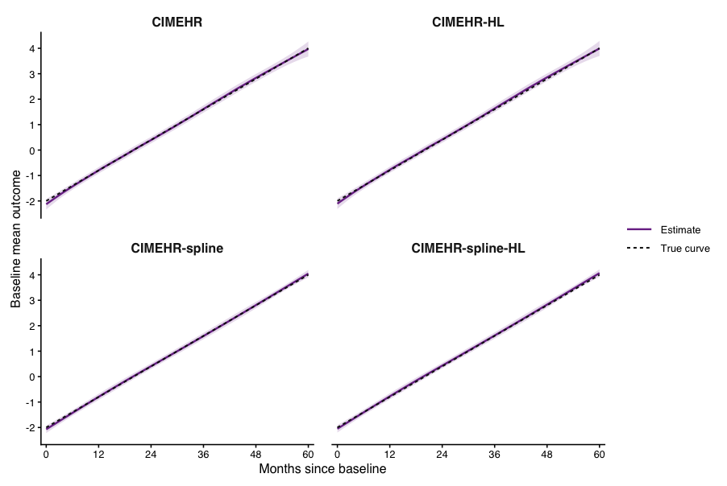

Baseline mean estimates with pointwise 95% participant-bootstrap confidence intervals. All four methods use 50 resamples, with every stage re-estimated in each resample. The black dashed curve is the generating baseline mean.

```r
population_figure
```

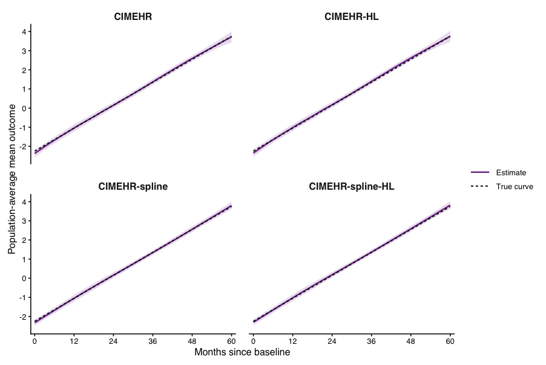

Population mean trajectories with pointwise 95% participant-bootstrap confidence intervals. Each curve averages Z = 0 and Z = 1 equally at X = 0. All four methods use 50 resamples, with every stage re-estimated in each resample. The black dashed curve is the generating population mean.

The native interface remains available: for example, `plot(bootstrap_curves[["cimehr population"]])` draws one fitted curve object. Set `conf.int = FALSE` in `plot()` to hide stored intervals without refitting. Change `conf.int` in `meanfit()` to request another confidence level. The bootstrap interface is also available for the supported Liang and EHRJoint methods.

## 6. Locate the included results or export your own

The package includes PDFs of the two comparison figures and CSV tables, as well as the code used above. These are available after installation without rerunning the fits or bootstrap:

```r
results_directory <- system.file("examples", "results", package = "CIMEHR")
list.files(results_directory)
```

```
#> [1] "all_stage_estimates.csv"        "baseline_95CI.pdf"
#> [3] "baseline_population_curves.csv" "bootstrap_summary.csv"
#> [5] "outcome_estimates.csv"          "population_trajectory_95CI.pdf"
```

```r
system.file("examples", "cimehr_workflow.R", package = "CIMEHR")
```

```
#> [1] "/private/var/folders/vc/ndslnt5n52361c8cdskwj0_ddknq6f/T/RtmpMT0Vo8/Rinst109ad36a66273/CIMEHR/examples/cimehr_workflow.R"
```

`all_stage_results` contains the complete visiting, observation, and outcome parameter table calculated above. `outcome_results` is its 16-row fixed-effect and shared-loading comparison. `curve_results` contains the unrounded fitted curves, SEs, intervals, and generating means used in the figures.

The function below exports these newly calculated results only when called with an explicit destination. Running the workflow does not automatically write result files in the working directory.

```r
export_results <- function(directory) {
  stopifnot(is.character(directory), length(directory) == 1L,
            !is.na(directory), nzchar(directory))
  dir.create(directory, recursive = TRUE, showWarnings = FALSE)
  if (!dir.exists(directory)) stop("The output directory could not be created.")
  write.csv(outcome_results, file.path(directory, "outcome_estimates.csv"),
             row.names = FALSE)
  write.csv(all_stage_results, file.path(directory, "all_stage_estimates.csv"),
             row.names = FALSE)
  write.csv(curve_results, file.path(directory, "baseline_population_curves.csv"),
             row.names = FALSE)
  write.csv(bootstrap_summary, file.path(directory, "bootstrap_summary.csv"),
             row.names = FALSE)
  ggsave(file.path(directory, "baseline_95CI.pdf"), plot = baseline_figure,
         width = 9.4, height = 6.3, device = grDevices::pdf, useDingbats = FALSE)
  ggsave(file.path(directory, "population_trajectory_95CI.pdf"),
         plot = population_figure, width = 9.4, height = 6.3,
         device = grDevices::pdf, useDingbats = FALSE)
  invisible(list.files(directory, full.names = TRUE))
}
```

For example, call `export_results("~/CIMEHR_results")` after running the script to save the regenerated files in that directory. See `?CIMEHR`, `?CIMEHR_spline`, `?summary_outcome`, and `?meanfit` for the full argument definitions and the scope of each inference option.